# load library

##### Cluster 1

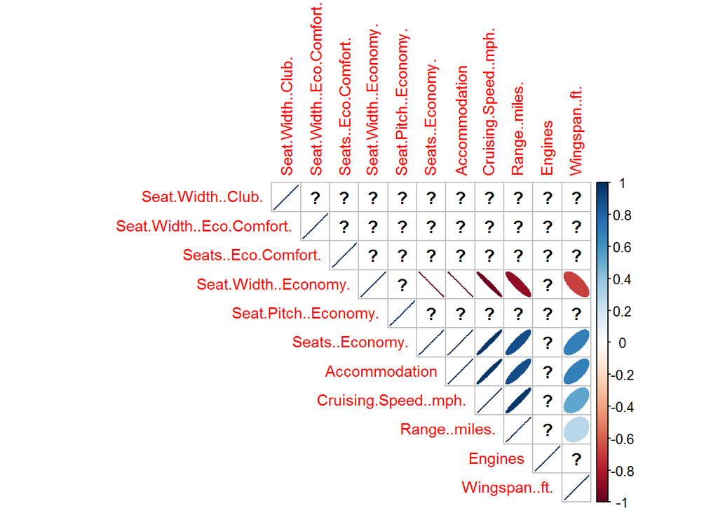

```r
h<-cluster1[,c(1,10,12,13,14,15,16,17,18,19,20)]
corrplot(cor(h), type="upper", method="ellipse", tl.cex=0.9)
```

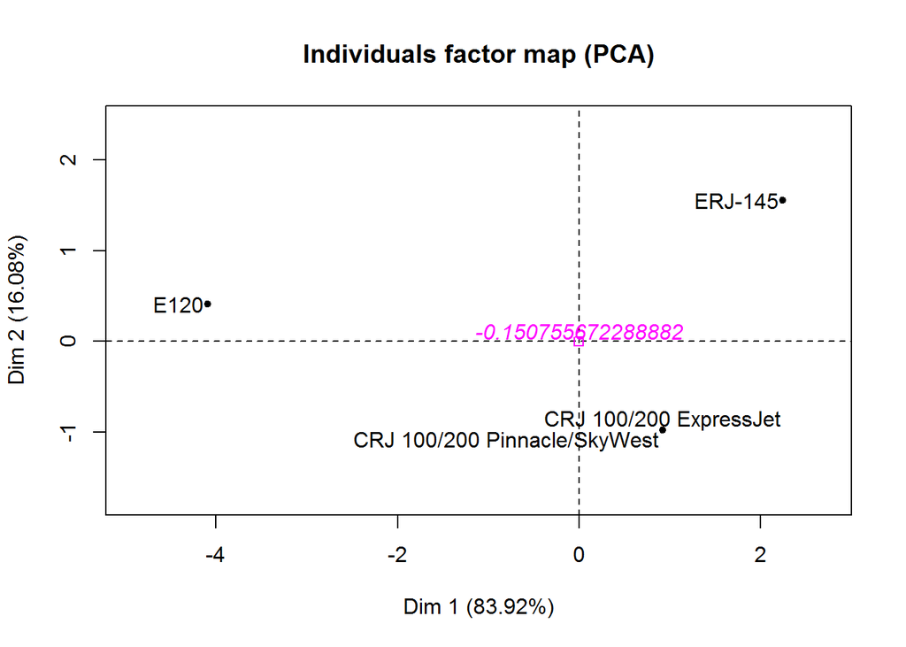

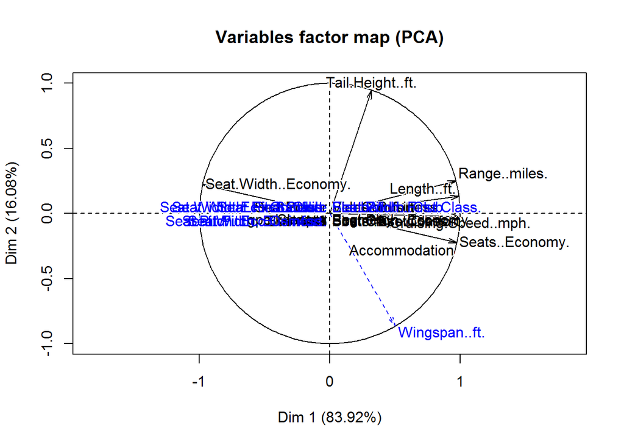

```r
PcaCl1=PCA(cluster1,quali.sup=29,quanti.sup = c(1,2,4,5,7,8,10,11,26,27,20))
```

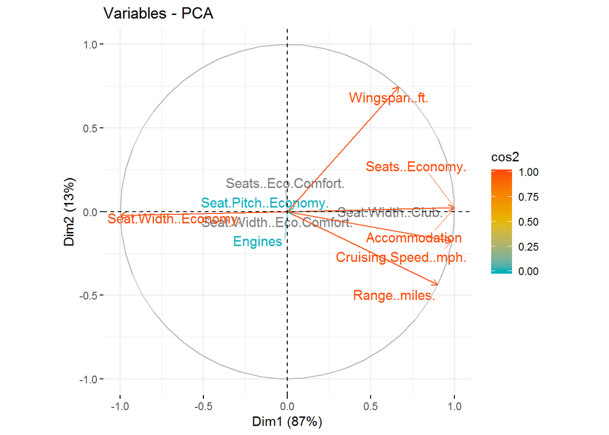

```r
res.pca <- PCA(h, graph = FALSE)

fviz_pca_var(res.pca, col.var = "cos2",
             gradient.cols = c("#00AFBB", "#E7B800", "#FC4E07"),
             repel = TRUE
             )
```

```r
cluster1_sof <- fusion[which(fusion$groupe==1),]
aggregate(cluster1_sof,by=list(cluster1_sof$groupe),FUN=mean)
```

```
##   Group.1 Seat.Width..Club. Seat.Pitch..Club. Seat..Club.
## 1       1                 0                 0           0
##   Seat.Width..First.Class. Seat.Pitch..First.Class. Seats..First.Class.
## 1                        0                        0                   0
##   Seat.Width..Business. Seat.Pitch..Business. Seats..Business.
## 1                     0                     0                0
##   Seat.Width..Eco.Comfort. Seat.Pitch..Eco.Comfort. Seats..Eco.Comfort.
## 1                        0                        0                   0
##   Seat.Width..Economy. Seat.Pitch..Economy. Seats..Economy. Accommodation
## 1               17.525                   31            44.5          44.5
##   Cruising.Speed..mph. Range..miles. Engines Wingspan..ft.
## 1               464.25        1236.5       2        67.458
##   Tail.Height..ft. Length..ft. Wifi Video Power Satellite Flat.bed Sleeper
## 1         20.95725    84.81075    0     0     0         0        0       0
##   Club First.Class Business Eco.Comfort Economy groupe
## 1    0           0        0           0       1      1
```

- this cluster is almost all econmy with no buissness seats and no first class !!
- Faible cluster en Economy Class, Accomodation,CruisingSpeed, Range, Wingspan, Tail Height et Length - Absence de Business Class, First Class, EcoComfortClass,Wifi, Vidéo, Power, Satellite, Flat-bed et Sleeper dans ce cluste
- this cluster have the cheapest planes like E120 and ERJ-145 those planes have low seat number , almost nothing but the basic , tunisair should avoide the planes that are in this cluster